# Dynamic nonlinear impacts of oil price returns and financial uncertainties on credit risks of oil-exporting countries - ScienceDirect

## [Energy Economics](https://www.sciencedirect.com/journal/energy-economics)

[Volume 88](https://www.sciencedirect.com/journal/energy-economics/vol/88/suppl/C), May 2020, 104747

# Dynamic nonlinear impacts of oil price returns and financial uncertainties on credit risks of oil-exporting countries

[Nader Naifar <sup>a</sup> <sup>b</sup>](https://www.sciencedirect.com/author/56108302500/nader-a-naifar), [Syed Jawad Hussain Shahzad <sup>c</sup> <sup>d</sup>](https://www.sciencedirect.com/author/56365998900/syed-jawad-hussain-shahzad), [Shawkat Hammoudeh <sup>e</sup> <sup>f</sup>](https://www.sciencedirect.com/author/6602687914/shawkat-m-hammoudeh)

https://doi.org/10.1016/j.eneco.2020.104747[Get rights and content](https://s100.copyright.com/AppDispatchServlet?publisherName=ELS&contentID=S0140988320300864&orderBeanReset=true)

Full text access

## Highlights

- •

  We use different quantile approaches.
- •

  Oil price returns affect the sovereign credit risk premium.
- •

  The non-GCC exporters are the most countries affected by oil prices.
- •

  Countries not affected have huge sovereign wealth funds.

## Abstract

This paper investigates the dynamic and nonlinear impact of oil price returns on the sovereign [credit default swap](https://www.sciencedirect.com/topics/economics-econometrics-and-finance/credit-derivative) (CDS) spreads for the oil-rich countries of the Gulf Cooperation Council (GCC) and other important oil-exporting countries, namely Venezuela, [Mexico](https://www.sciencedirect.com/topics/earth-and-planetary-sciences/mexico) and Russia. We employ the standard quantile regression analysis, the rolling quantile regression, and finally, the Quantile-on-quantile (QQ) approach that allows one to investigate the dependence dynamics of the sovereign CDS spreads under different credit market conditions. The empirical results show that oil price returns significantly and favorably decrease the sovereign credit risk premium of the non-GCC oil-exporting countries under consideration. However, the results also suggest no or little impact on the sovereign credit risk premium of Saudi Arabia, UAE and Norway, which have the most significant [sovereign wealth funds](https://www.sciencedirect.com/topics/economics-econometrics-and-finance/sovereign-wealth-fund) in the world. The negative (i.e. favorable) impact of oil price returns on the sovereign CDS spreads, where present, gradually increases with the quantile level and is the highest during the bullish credit market conditions. The results also show that those CDS spreads are more sensitive to the global bond market uncertainty factor than to the global equity market uncertainty factor.

## Keywords

Sovereign CDS spreads

Oil volatility

Financial uncertainty

Quantile-on-Quantile approach

## JEL classification

C1

G1

G2

## 1. Introduction

The credit default swap (CDS) is the most common type of credit derivatives that offers protection against default and other major credit events. The market price of a CDS (called CDS premium or spread) reflects the risk of the underlying credit as it widens in the face of financial difficulties and rising dangers in the national economy. Sovereign CDSs are bilateral contracts between a buyer and a seller where the seller is offering protection against credit events that may affect a sovereign borrower. Since sovereign CDS contracts are generally used to hedge adverse credit events by a sovereign borrower, it will be interesting to examine how the sovereign CDS spreads of oil-exporting countries are impacted by oil prices, expected risks, and uncertainty factors of the financial markets under different market conditions (normal, bullish and bearish markets).

Our research has become more relevant and timelier for the oil-exporting countries in the wake of the recent collapses of oil prices that dropped from $100 in June 2014 to $26 in February 2016 and from $60 to $30 in the first quarter of 2020. This grave instability of oil prices has jolted the sovereign CDS markets, particularly those of the oil-exporting countries like Russia and Venezuela (Chuffart and Hooper, 2019). A widening of a CDS spread in response to a credit event or recently to an oil price shock indicates an increase in the level of the credit risk of the affected countries, while a narrowing in the spread reveals a decrease in the credit risk of those countries. On the other hand, financial risk and uncertainty factors should in theory affect the economy by increasing the risk that investors perceive they will face when making economic decisions. The financial uncertainty is closely related to unexpected credit changes that may affect investment decisions. Financial risk indices such as VIX and MOVE gauge market risks in the form of expected volatility in the equity and bond markets, respectively.

There are numerous recent empirical studies on sovereign CDS markets. The crucial CDS studies include Longstaff et al. (2011) and Pan and Singleton (2008) among others, but those studies do not adequately investigate the impact of the changes in the financial risk and uncertainties factors on sovereign CDS markets, particularly the credit markets of major oil-producing countries. These studies find a strong relationship between the [U.S.](https://www.sciencedirect.com/topics/earth-and-planetary-sciences/united-states-of-america) CDS spreads and the VIX index. Baum and Wan (2010) indicate that sovereign CDS spreads rise under [economic policy uncertainty](https://www.sciencedirect.com/topics/economics-econometrics-and-finance/economic-policy-uncertainty). They also argue that [interest rate risks](https://www.sciencedirect.com/topics/economics-econometrics-and-finance/interest-rate-risk) and [macroeconomic](https://www.sciencedirect.com/topics/economics-econometrics-and-finance/macroeconomics) uncertainty factors are significant determinants of CDS spreads. Ang and Longstaff (2013) find that the [systemic risk](https://www.sciencedirect.com/topics/engineering/systemic-risk) component of the sovereign CDS spreads is influenced by global financial factors. Alter and Schüler (2012) show evidence of [joint](https://www.sciencedirect.com/topics/engineering/joints-structural-components) dynamics from banks to sovereign CDS before the public rescue programs for the financial sector. Dieckmann and Plank (2012) test whether Western European sovereign CDS spreads capture a transfer of risk from the private sector to the public sector over the period January 2007 to April 2010. They indicate that sovereign CDS spreads rose in the European region after the recent [global financial crisis](https://www.sciencedirect.com/topics/engineering/global-financial-crisis).

Few recent studies examine the impact of oil prices on the sovereign credit risk. Sharma and Thuraisamy (2013), for example, investigate the impact of oil price uncertainty on sovereign CDS spreads, using data for eight Asian countries. They find that oil price uncertainty predicts out-of-sample CDS spread returns for six out of those eight countries, namely Malaysia, Indonesia, [Japan](https://www.sciencedirect.com/topics/engineering/japan), the Philippines, Vietnam and South Korea. Bouri et al. (2018) investigate the dependence between crude oil implied volatility shocks and BRICS sovereign risk. Overall, they find that the oil exporters Russia and Brazil are more sensitive to positive shocks in oil volatility, while the oil importers China and India are more sensitive to negative shocks.

The recent oil collapse, the 2010–2012 European sovereign debt crisis and the elevation in economic uncertainty have motivated us to investigate the nonlinear impact of changes in oil price returns and volatility and financial uncertainty factors on the CDS spreads of GCC countries (namely Bahrain, Qatar, Saudi Arabia and United Arab Emirates (UAE)), for which there are adequate data on CDS spreads, and other important oil-exporting countries (namely [Mexico](https://www.sciencedirect.com/topics/earth-and-planetary-sciences/mexico), Norway, Russia and Venezuela). These countries are different in regard to their [relative dependence](https://www.sciencedirect.com/topics/engineering/relative-dependence) on oil revenues, amounts of foreign reserves they hold, levels of their [sovereign wealth funds](https://www.sciencedirect.com/topics/economics-econometrics-and-finance/sovereign-wealth-fund) and sensitivity to uncertainty. We use the WTI crude oil price to account for the oil [price dynamics](https://www.sciencedirect.com/topics/earth-and-planetary-sciences/price-dynamics) and the CBOE crude oil volatility index (OVX) to take into consideration the oil price uncertainty. Other relevant uncertainty indexes include the global bond market uncertainty as represented by the Merrill Lynch option volatility estimate (MOVE) index, the stock market uncertainty as captured by the CBOE volatility index (VIX) and the global market bond price risk captured by the US 10-year Treasury [bond interest rate](https://www.sciencedirect.com/topics/economics-econometrics-and-finance/bond-interest-rate) (US bond).

First, we initially utilize the quantile regression analysis (QRA hereafter) which allows one to investigate the impact of different factors on the sovereign CDS spreads of oil-exporting-countries under different credit market conditions, i.e., bearish credit markets (lower quantiles), bullish credit markets (upper quantiles) or normal credit markets (intermediate quantiles).<sup>1</sup> Next, we use the quantile-on-quantile approach (QQA) advanced by Sim and Zhou (2015) to examine relationships across the variables that are specific to the location of the [dependent variable](https://www.sciencedirect.com/topics/engineering/dependent-variable) and each of its relevant covariates over their respective density supports. Moreover, QRA allows for identifying shifts in the propagation mechanism across variables when shocks hit the dependent variable, while QQA extends this to the occurrence of shocks on both the dependent variable and one relevant covariate. This analysis is beneficial to market participants and policymakers by serving as a robustness check since both QRA and QQA have a common another but different advantages.

This study adds to the related literature on sovereign CDS markets in several ways. First, it investigates whether there are nonlinear impacts from oil and global financial risk and uncertainty factors to the credit risk of oil-exporting countries, a topic that has become timelier and more relevant after the recent collapses in oil prices and increases in [geopolitical risk](https://www.sciencedirect.com/topics/economics-econometrics-and-finance/geopolitical-risks). Second, if such a relationship exists, it addresses the question: under which market conditions is this relationship stronger or weaker, given the fact that sovereign CDS spreads go through boom, normal and bust periods? Third, our empirical methodology allows us to make a cascade of analyses starting from the standard QRA and moving to QQA, permitting more relationships affected by the location, the scale and the shape of either the response variable and/or the covariates. Finally, the diversity of the markets under consideration allows us to make a comparison between oil-rich countries during different periods that include the collapse of oil prices in 2008 and 2014.

This research should be useful to investors and policymakers, particularly in the oil-exporting countries since it investigates the impact of oil and global financial and uncertainty factors on the credit risks of those countries under different market conditions.

The remainder of this study is organized as follows. Section 2 describes the data and provides preliminary analyses. Section 3 introduces the research methodology. Section 4 presents the empirical results, and Section 5 concludes the study.

## 2. Data description and preliminary analyses

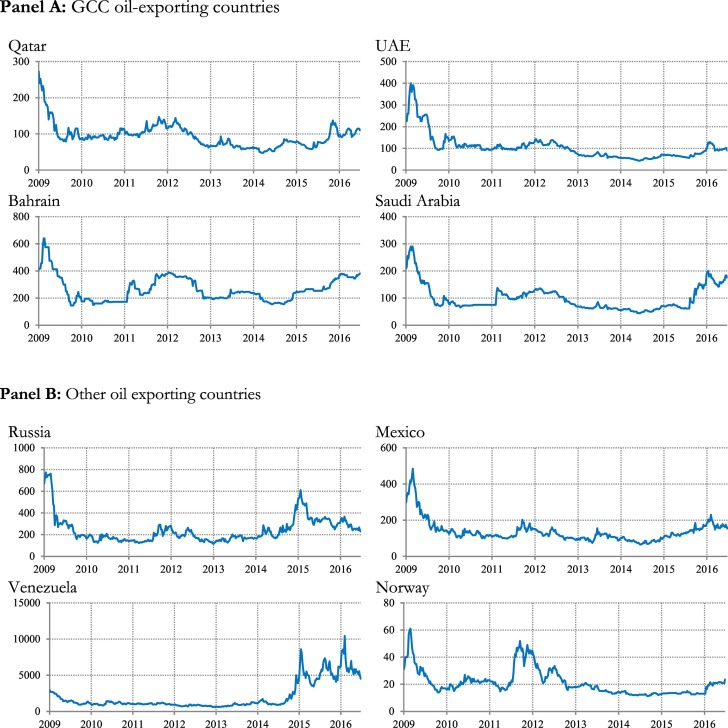

Fig. 1. Trend of SCDS Spread (basis points – 5-year maturity).

To account for the effect of global equity market risks on the sovereign CDS spreads of the countries under consideration, we use the VIX equity index - the Chicago Board Options Exchange (CBOE) Volatility Index for the stock market. This index is also known as the fear index which measures the implied volatility of a wide range of options based on the S&P 500 index. To account for the market bond [price dynamics](https://www.sciencedirect.com/topics/earth-and-planetary-sciences/price-dynamics), we use the US 10-year Treasury bond interest rate (US bond rate). Moreover, to capture the effect of financial uncertainty on global bond markets, we use VIX for the bond market (the MOVE index). The MOVE index measures the implied volatility of the [U.S.](https://www.sciencedirect.com/topics/earth-and-planetary-sciences/united-states-of-america) Treasury market and is considered by international investors as a useful indicator to assess the psyche of the world's credit markets. To account for the effect of the global commodity market, we use the price of the WTI crude oil price to represent oil prices. Finally, to take into consideration market expectations of volatility of crude oil prices, we use the OVX index - the CBOE crude oil volatility index—which applies the VIX methodology to options on the United States Oil Fund. All data of our study are sourced from DataStream. Fig. 2 plots the time-variations of risk and uncertainty indices from January 2009 to June 2016.

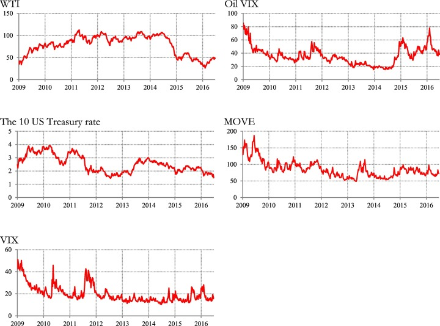

Fig. 2. Trend of explanatory variables (financial risk and uncertainty factors).

The [descriptive statistics](https://www.sciencedirect.com/topics/economics-econometrics-and-finance/descriptive-statistics) of the data series are shown in Table 1.

Table 1. [Stochastic properties](https://www.sciencedirect.com/topics/engineering/stochastic-property) of the data.

| Empty Cell | Mean | Std. dev. | Skewness | Kurtosis | J-B | ADF | KPSS |
| --- | --- | --- | --- | --- | --- | --- | --- |
| Panel A: GCC SCDS indices |  |  |  |  |  |  |  |
| Qatar | −0.0023 | 0.0607 | 0.0367<sup>⁎</sup> | 6.056<sup>⁎⁎</sup> | 151.8<sup>⁎⁎⁎</sup> | −17.31<sup>⁎⁎⁎</sup> | 0.2082 |
| UAE | −0.0023 | 0.0597 | 0.3514 | 8.152 | 439.3<sup>⁎⁎⁎</sup> | −15.45<sup>⁎⁎⁎</sup> | 0.0499 |
| Bahrain | −0.0002 | 0.0550 | 0.4685 | 13.49 | 1804.8<sup>⁎⁎⁎</sup> | −9.982<sup>⁎⁎⁎</sup> | 0.0983 |
| Saudi Arabia | −0.0004 | 0.0656 | 2.5849 | 20.10 | 5187.4<sup>⁎⁎⁎</sup> | −15.58<sup>⁎⁎⁎</sup> | 0.1176 |
| Panel B: Other oil-exporting countries' SCDS indices |  |  |  |  |  |  |  |
| Russia | −0.0028 | 0.0917 | −0.0894 | 6.239 | 171.0<sup>⁎⁎⁎</sup> | −18.82<sup>⁎⁎⁎</sup> | 0.2360 |
| Mexico | −0.0017 | 0.0790 | 0.1429 | 4.404 | 33.36<sup>⁎⁎⁎</sup> | −18.59<sup>⁎⁎⁎</sup> | 0.0943 |
| Venezuela | 0.0011 | 0.0937 | 0.8141 | 6.126 | 201.9<sup>⁎⁎⁎</sup> | −16.59<sup>⁎⁎⁎</sup> | 0.2432 |
| Norway | −0.0007 | 0.0691 | 0.7646 | 6.590 | 247.4<sup>⁎⁎⁎</sup> | −16.20<sup>⁎⁎⁎</sup> | 0.0646 |
| Panel C: Oil returns, oil volatility and other uncertainty factors |  |  |  |  |  |  |  |
| WTI | 0.0004 | 0.0489 | −0.0069 | 4.938 | 61.07<sup>⁎⁎⁎</sup> | −18.16<sup>⁎⁎⁎</sup> | 0.2611 |
| Oil VIX | −0.0021 | 0.0957 | 0.6976 | 4.330 | 60.41<sup>⁎⁎⁎</sup> | −21.98<sup>⁎⁎⁎</sup> | 0.1423 |
| VIX | −0.0026 | 0.1391 | 0.3944 | 4.744 | 59.56<sup>⁎⁎⁎</sup> | −22.11<sup>⁎⁎⁎</sup> | 0.0660 |
| US10TR | −0.0013 | 0.0501 | −0.1880 | 3.930 | 16.35<sup>⁎⁎⁎</sup> | −18.94<sup>⁎⁎⁎</sup> | 0.1124 |
| MOVE | −0.0019 | 0.0877 | 0.3155 | 3.619 | 12.70<sup>⁎⁎⁎</sup> | −20.14<sup>⁎⁎⁎</sup> | 0.0424 |

Notes: All variables are in log difference. J-B stands for the Jarque-Bera test of normality. ADF and KPSS are the empirical statistics of the Augmented Dickey-Fuller (1979) unit root tests, and the Kwiatkowski et al. (1992) stationarity test, respectively.

**⁎⁎⁎**

Denotes the rejection of the null hypotheses of normality and unit root at the 1% significance level.

**⁎⁎**

Denotes the rejection of the null hypotheses of normality and unit root at the 5% significance level.

**⁎**

Denotes the rejection of the null hypotheses of normality and unit root at the 10% significance level.

Table 1 shows the properties of the log difference of the CDS spreads and other variables to ensure the stationarity of the regression estimates. Panel A of Table 1 shows that the [standard deviation](https://www.sciencedirect.com/topics/economics-econometrics-and-finance/measure-of-dispersion) of the CDS spreads of Saudi Arabia, which is the world's largest oil exporter, is the highest compared to those of the other GCC countries. Bahrain, which has the most open GCC financial market and receives a steady stream of foreign aid from Saudi Arabia, has the lowest standard deviation of the CDS spreads among the GCC countries. For the four non-GCC oil-exporting countries, Venezuela in Panel B has the highest standard deviation of the CDS spreads of all the oil-exporting countries considered in this study including Russia. On the other hand, Norway which has the greatest [sovereign wealth fund](https://www.sciencedirect.com/topics/economics-econometrics-and-finance/sovereign-wealth-fund) in the world and is a relatively more diversified economy has the lowest CDS volatility in this group. As expected, the CDS spread volatility for the non GCC oil-exporting countries is higher than the volatility of the GCC CDS spreads. The reason for this anecdotal finding is probably due to the GCC markets being relatively closed to global investors, compared to the markets of the other countries considered in this study which have to deal with the full impact of [global financial crises](https://www.sciencedirect.com/topics/engineering/global-financial-crisis).

By referring to the skewness, kurtosis coefficients, and J-B statistics, one can confirm that the normality hypothesis of all the datasets is rejected. To initially establish that we are dealing with stationary time series, which is a requirement of the quantile regression and the causality-in-quantiles test, we have implemented the augmented Dickey and Fuller (ADF; 1979) unit root test and the Kwiatkowski, Phillips, Schmidt, and Shin (KPSS; 1992) stationarity test. The results of the unit root and the stationarity tests strongly suggest that all the series are stationary processes in the log difference form at the conventional levels. The non-normality, serial correlations and conditional heteroskedasticity in the distribution of all datasets pay the way for performing a quantile-based analysis.

Table 2 reports the [correlation coefficients](https://www.sciencedirect.com/topics/earth-and-planetary-sciences/correlation-coefficient) of the log difference between the sovereign CDSs and the risk and uncertainty factors for those oil-exporting countries over the total sample period.

Table 2. Linear correlations between the sovereign CDS (SCDS) and oil and uncertainty factors.

| Empty Cell | WTI | Oil VIX | VIX | US10TR | MOVE |
| --- | --- | --- | --- | --- | --- |
| Panel A: GCC SCDS indices |  |  |  |  |  |
| Qatar | −0.0350 | 0.1018<sup>⁎⁎</sup> | 0.0599 | −0.0068 | 0.0549 |
|  | (−0.6907) | (2.0152) | (1.1829) | (−0.1342) | (1.0839) |
| UAE | −0.1992<sup>⁎⁎⁎</sup> | 0.2323<sup>⁎⁎⁎</sup> | 0.2799<sup>⁎⁎⁎</sup> | −0.1215<sup>⁎⁎</sup> | 0.2820<sup>⁎⁎⁎</sup> |
|  | (−4.0032) | (4.7055) | (5.7434) | (−2.4107) | (5.7889) |
| Bahrain | −0.0805 | 0.1011<sup>⁎⁎</sup> | 0.0863<sup>⁎</sup> | −0.0160 | 0.0910<sup>⁎</sup> |
|  | (−1.5906) | (2.0021) | (1.7064) | (−0.3158) | (1.8008) |
| Saudi Arabia | −0.1594<sup>⁎⁎⁎</sup> | 0.1474<sup>⁎⁎⁎</sup> | 0.2315<sup>⁎⁎⁎</sup> | −0.0933<sup>⁎</sup> | 0.1787<sup>⁎⁎⁎</sup> |
|  | (−3.1800) | (2.9352) | (4.6881) | (−1.8465) | (3.5774) |
| Panel B: Other oil-exporting countries' SCDS indices |  |  |  |  |  |
| Russia | −0.3820<sup>⁎⁎⁎</sup> | 0.3763<sup>⁎⁎⁎</sup> | 0.4879<sup>⁎⁎⁎</sup> | −0.3235<sup>⁎⁎⁎</sup> | 0.2581<sup>⁎⁎⁎</sup> |
|  | (−8.1430) | (7.9992) | (11.010) | (−6.7332) | (5.2616) |
| Mexico | −0.4125<sup>⁎⁎⁎</sup> | 0.3699<sup>⁎⁎⁎</sup> | 0.5692<sup>⁎⁎⁎</sup> | −0.2778<sup>⁎⁎⁎</sup> | 0.3738<sup>⁎⁎⁎</sup> |
|  | (−8.9205) | (7.8414) | (13.638) | (−5.6953) | (7.9376) |
| Venezuela | −0.4091<sup>⁎⁎⁎</sup> | 0.2886<sup>⁎⁎⁎</sup> | 0.4168<sup>⁎⁎⁎</sup> | −0.2062<sup>⁎⁎⁎</sup> | 0.2988<sup>⁎⁎⁎</sup> |
|  | (−8.8323) | (5.9378) | (9.0319) | (−4.1512) | (6.1685) |
| Norway | −0.1373<sup>⁎⁎⁎</sup> | 0.2002<sup>⁎⁎⁎</sup> | 0.2476<sup>⁎⁎⁎</sup> | −0.2161<sup>⁎⁎⁎</sup> | 0.1339<sup>⁎⁎⁎</sup> |
|  | (−2.7305) | (4.0244) | (5.0344) | (−4.3602) | (2.6616) |

Note: All variables are in log differences. The t-statistics are in parenthesis.

**⁎⁎⁎**

Indicates significance at the 1% level.

**⁎⁎**

Indicates significance at the 5% level.

**⁎**

Indicates significance at the 10% level.

## 3. Research methodology

Firstly, we apply the standard quantile regression analysis (QRA) which allows one to investigate the dependence dynamics of the CDS spreads for the oil-rich GCC countries, and the other major oil exporters under different market circumstances (normal, bearish and bullish states). Secondly, in order to perform the robustness check of the empirical results, we apply the quantile-on-quantile analysis approach (QQA) which was advanced by Sim and Zhou (2015).

### 3.1. Quantile regression analysis

The basic quantile regression is introduced by Koenker and Bassett (1978) and involves the consideration of a set of [regression curves](https://www.sciencedirect.com/topics/engineering/regression-curve) that differ across the different quantiles of the conditional distribution of the [dependent variable](https://www.sciencedirect.com/topics/engineering/dependent-variable). To account for the dynamics between the CDS spreads and the different explanatory variables, we rely on the quantile regression model for the *τth* quantile of the CDS distribution (*y*<sub>*t*</sub>), *Q*<sub>*τ*</sub>(*y*<sub>*t*</sub>), that is specified as:(1)$Qτyt=δ0,τ+δ1,τ′Zt$where *Z*<sub>*t*</sub> may include lags of both the target variable and lags of the control covariates. The coefficients included in *δ*<sub>1</sub> allow one to detect the presence of the impacts of the covariates (either the CDS spreads, oil prices, and financial and uncertainty factors) at the quantile of order *τ*.

The quantile regression does not require any distributional assumptions regarding population and can estimate the parameters non-parametrically. The quantiles may be characterized as the solution to a simple optimization problem (e.g., Koenker and Bassett, 1978; Koenker and Hallock, 2003; Koenker, 2005). More formally, taking a random sample *y*<sub>*1*</sub>, *y*<sub>*2*</sub>, *y*<sub>*3*</sub>, …*y*<sub>*n*</sub> with the empirical distribution function $F^yα=1n≠yi≤α$, the empirical unconditional quantile function is defined as(2)$Q^yτ=F^y−1τ=infα/F^yα≥τ$

According to Koenker and Bassett (1978), the quantiles may be expressed as the solution to a [minimization problem](https://www.sciencedirect.com/topics/engineering/minimization-problem):(3)$Q^yτ=argminα∑i:yi≥ατyi−α+∑i:yi<α1−τyi−α=argminα∑iρτyi−α$

Using the check function$ρτz=τz:z≥0τ−1z:z<0$

In the case of the regression of [linear dependence](https://www.sciencedirect.com/topics/engineering/linear-dependence) on a vector of exogenous variables (*X*), the linear conditional quantile function can be written as follows:(4)$Qyτ/X=inf(α/Fyα/X≥τ=∑kβkτXk=X′βτ$

### 3.2. Quantile-on-quantile approach

We briefly describe the key features of the quantile-on-quantile approach proposed by Sim and Zhou (2015) and the model specification used to investigate the impact of oil price returns on SCDS of the oil-exporting countries across the range of conditional quantiles. The QQ approach, as a generalization of the standard quantile regression, is a combination of the quantile regression and a nonparametric estimation, enabling one to examine how the quantiles of a variable affect the conditional quantiles of another variable. In the framework of the present study, the QQ approach has its starting point in the following nonparametric quantile regression model:(5)$SCDSt=βθOilt+utθ$where S*CDS*<sub>*t*</sub> represents the sovereign CDS returns of a given country in period *t*, *Oil*<sub>*t*</sub> denotes the oil price returns at period *t*, *θ* is the *θth* quantile of the conditional distribution of the SCDS returns and *u*<sub>*t*</sub><sup>*θ*</sup> is a quantile [error term](https://www.sciencedirect.com/topics/engineering/error-term) whose conditional *θth* quantile is equal to zero. The *β*<sup>*θ*</sup>(·) is an unknown function as we have no prior information on how the SCDS and oil price returns are linked.

This standard quantile regression model allows the effect of oil returns to vary across the different quantiles of SCDS returns; however, this model is unable to capture the dependence in its entirety. We posit that large or small positive/negative oil shocks may have a differential influence on the SCDS markets and that the SCDSs may also react asymmetrically to the negative and positive oil shocks.

Therefore, to examine the relationship between the *θth* quantile of SCDS returns and the *τth* quantile of oil returns, denoted by *Oil*<sup>*τ*</sup>, Eq. (5) is examined in the neighborhood of *Oil*<sup>*τ*</sup> using local linear regression. As *β*<sup>*θ*</sup>(·) is unknown, this function can be approximated through a first-order [Taylor expansion](https://www.sciencedirect.com/topics/engineering/taylor-expansion) around a quantile *Oil*<sup>*τ*</sup>, such that:(6)$βθOilt≈βθOilτ+βθ′OilτOilt−Oilτ$where *β*<sup>*θ*′</sup> is the partial derivative of *β*<sup>*θ*</sup>(*Oil*<sub>*t*</sub>) with respect to *Oil* which is also called the marginal effect or the response and is similar in interpretation to the coefficient (slope) in a linear regression model. Now, *β*<sup>*θ*</sup>(*Oil*<sup>*τ*</sup>) and *β*<sup>*θ*′</sup>(*Oil*<sup>*τ*</sup>) can be renamed as *β*<sub>0</sub>(*θ*, *τ*) and *β*<sub>1</sub>(*θ*, *τ*), respectively, and Eq. (6) can be rewritten as:(7)$βθOilt≈β0θτ+β1θτOilt−Oilτ$

By substituting Eq. (7) in Eq. (5), the following SCDS equation is obtained:(8)$SCDSt=β0θτ+β1θτOilt−Oilτ⏟∗+utθ$

The term (*) in Eq. (8) is the *θth* conditional quantile of the SCDS returns. Unlike the standard conditional quantile function, Eq. (8) captures the overall dependence structure between the *θth* quantile of the SCDS returns and the *τth* quantile of the oil returns as the parameters *β*<sub>0</sub> and *β*<sub>1</sub> are doubly indexed in *θ* and *τ*.

To estimate Eq. (8), it is necessary to replace *Oil*<sub>*t*</sub> and *Oil*<sup>*τ*</sup> by their empirical counterparts $Oil^t$ and $Oil^τ$, respectively. The local linear regression estimates of the parameters *b*<sub>0</sub> and *b*<sub>1</sub> are obtained by solving the following minimization problem:(9)$minb0,b1∑i=1nρθSCDSt−b0−b1Oil^t−Oil^τKFnOil^t−τh$where *ρ*<sub>*θ*</sub>(*u*) is the quantile loss function, defined as *ρ*<sub>*θ*</sub>(*u*) = *u*(*θ* − *I*(*u* < 0)) and *I* is the usual indicator function. *K*(·) denotes the kernel function and *h* is the bandwidth parameter of the kernel. The [Gaussian kernel](https://www.sciencedirect.com/topics/engineering/gaussian-kernel), because of its computational simplicity and efficiency, is used to weight the observations in the neighborhood of *Oil*<sup>*τ*</sup>. More specifically, in our analysis these weights are inversely related to the distance between the empirical distribution function of $Oil^t$, denoted by $FnOil^t=1n∑k=1nIOil^k<Oil^t$, and the value of the distribution function that corresponds with the quantile *Oil*<sup>*τ*</sup>, denoted by *τ*. A bandwidth parameter *h* = 0.05 is used following Sim and Zhou (2015).

## 4. Empirical results and discussion

In this section, we report the results of the QRA to investigate the dependence dynamics of the sovereign CDS spreads under different market circumstances including the bearish, bullish and normal states. Secondly, we report the results of the rolling-window-based QRA estimates for the impact of oil returns on SCDS spreads. Finally, we report the results of the QQA.

### 4.1. Quantile regression results and discussion

Table 3. Quantile regression parameter estimates for the impact of oil returns on SCDS spreads.

| Quantiles | 0.05 | 0.1 | 0.25 | 0.5 | 0.75 | 0.9 | 0.95 | OLS | Wald |
| --- | --- | --- | --- | --- | --- | --- | --- | --- | --- |
| Qatar | 0.068 | 0.064 | 0.026 | 0.000 | 0.131 | −0.087 | 0.192 | −0.010 | 5.50<sup>⁎⁎⁎</sup> |
|  | (0.278) | (0.158) | (0.089) | (0.069) | (0.089) | (0.098) | (0.202) | (0.073) |  |
| UAE | −0.117 | −0.244<sup>⁎</sup> | −0.063 | −0.033 | 0.048 | −0.057 | −0.227 | −0.123<sup>⁎</sup> | 1.35 |
|  | (0.219) | (0.127) | (0.126) | (0.074) | (0.084) | (0.145) | (0.149) | (0.067) |  |
| Bahrain | −0.314 | −0.164 | −0.060 | −0.001 | −0.033 | −0.061 | −0.197 | −0.066 | 0.53 |
|  | (0.435) | (0.123) | (0.043) | (0.002) | (0.040) | (0.103) | (0.229) | (0.066) |  |
| Saudi Arabia | −0.506<sup>⁎⁎</sup> | −0.302<sup>⁎</sup> | −0.175<sup>⁎</sup> | −0.012 | −0.061 | −0.044 | 0.026 | −0.123 | 3.92<sup>⁎⁎⁎</sup> |
|  | (0.199) | (0.170) | (0.097) | (0.063) | (0.080) | (0.104) | (0.173) | (0.076) |  |
| Russia | −0.374 | −0.273<sup>⁎</sup> | −0.315<sup>⁎⁎⁎</sup> | −0.307<sup>⁎⁎⁎</sup> | −0.380<sup>⁎⁎⁎</sup> | −0.583<sup>⁎⁎⁎</sup> | −0.518<sup>⁎⁎</sup> | −0.358<sup>⁎⁎⁎</sup> | 0.67 |
|  | (0.290) | (0.152) | (0.090) | (0.097) | (0.112) | (0.170) | (0.227) | (0.092) |  |
| Mexico | −0.372 | −0.413<sup>⁎</sup> | −0.377<sup>⁎⁎⁎</sup> | −0.415<sup>⁎⁎⁎</sup> | −0.358<sup>⁎⁎⁎</sup> | −0.420<sup>⁎⁎⁎</sup> | −0.515<sup>⁎⁎⁎</sup> | −0.378<sup>⁎⁎⁎</sup> | 0.75 |
|  | (0.298) | (0.183) | (0.119) | (0.099) | (0.091) | (0.086) | (0.137) | (0.073) |  |
| Venezuela | −0.403<sup>⁎</sup> | −0.452<sup>⁎</sup> | −0.395<sup>⁎⁎</sup> | −0.557<sup>⁎⁎⁎</sup> | −0.598<sup>⁎⁎⁎</sup> | −0.685<sup>⁎⁎⁎</sup> | −0.974<sup>⁎⁎⁎</sup> | −0.590<sup>⁎⁎⁎</sup> | 1.43 |
|  | (0.225) | (0.235) | (0.156) | (0.184) | (0.201) | (0.164) | (0.245) | (0.096) |  |
| Norway | −0.299 | −0.155 | −0.098 | 0.000 | −0.048 | 0.157 | 0.444<sup>⁎</sup> | 0.005 | 5.25<sup>⁎⁎⁎</sup> |
|  | (0.199) | (0.198) | (0.156) | (0.042) | (0.131) | (0.164) | (0.263) | (0.079) |  |

Note: Wald is the Wald test for the equality of coefficients across selected quantiles. Standard errors are in parenthesis.

**⁎⁎⁎**

Indicates significance at the 1% level.

**⁎⁎**

Indicates significance at the 5% level.

**⁎**

Indicates significance at the 10% level.

Explicitly, Table 3 indicates that oil returns impact the sovereign CDS spreads across all quantiles in the case of Venezuela, Mexico and Russia (except for extreme lower quantile (q = 0.05) in the case of Russia and Mexico). We also note that all coefficients of oil returns are negative (favorable), and thus a decrease in oil prices leads to an increase in the credit risk premium, and in turn, an increase in the sovereign CDS spreads for those oil-sensitive countries that do not have a significant wealth cushions. It is worth noting that the negative impact of oil returns on SCDS spreads increases in the upper quantiles of SCDS spreads, which implies that oil plays a higher role when risk premia are higher. This finding can be explained by the fact that those countries which are major oil exporters have huge oil reserves, and Venezuela tops the list of countries having the largest global proven oil reserves accounting for more than 24% of [OPEC's](https://www.sciencedirect.com/topics/earth-and-planetary-sciences/opec) total oil reserves. In addition, the economies of those countries depend heavily on oil returns, and then any drops and shocks in oil prices affect the economy, geopolitics and alliances' structure of those countries.<sup>5</sup>

According to [CNBC.com](http://cnbc.com/),<sup>7</sup> Norway's Government Pension Fund Global has invested in almost 9000 companies in 77 countries and includes equities, real estate and fixed-income assets. According to the Sovereign Wealth Fund Institute (SWFI), Norway followed by UAE and KSA have the largest wealth funds in our sample, which means that these countries have a good cushion against negative fluctuations in oil prices. Table 4 present the Sovereign wealth fund ranking in 2016.

Table 4. Sovereign wealth fund ranking in 2016.

| Sovereign wealth name | Country | US$/billion |
| --- | --- | --- |
| Norway Government Pension Fund Global | Norway | $847.6 |
| Abu Dhabi Investment Authority | UAE | $773 |
| SAMA Foreign Holdings | KSA | $632,3 |
| Qatar Investment Authority | Qatar | $256 |
| Russian Direct Investment Fund | Russia | $73.5 |
| New Mexico State Investment Council | Mexico | $19.8 |
| Mumtalaket Holding Company | Bahrain | $11.1 |
| Macroeconomic Stabilization Fund | Venezuela | $0.8 |

Note: We selected data for the year 2016 because the data sample of our study span the period from 2009 to 2016.

(Source: SWFI ranking).

Table 4 shows that the UAE wealth fund is the largest wealth fund in the Middle East and its portfolio spreads across 24 asset classes. Its average 20-year and 30-year annualized rates of return are 7.4% and 8.4% in dollar terms, respectively, as of the end of 2014. However, Russia, Mexico, and Venezuela do not have significant sovereign wealth funds to buffer them from oil shocks (see Table 4). These countries will experience considerable economic hardships when oil prices fall drastically.

Concerning the oil price implied volatility (OVX index), Table 5 presents the quantile regression parameter estimates for the impact of OVX on SCDS spreads.

Table 5. Quantile regression parameter estimates for the impact of OVX on SCDS spreads.

| Quantiles | 0.05 | 0.1 | 0.25 | 0.5 | 0.75 | 0.9 | 0.95 | OLS | Wald |  |  |  |
| --- | --- | --- | --- | --- | --- | --- | --- | --- | --- | --- | --- | --- |
| Qatar | 0.011 | 0.128<sup>⁎</sup> | 0.059 | 0.001 | −0.009 | 0.112 | 0.239 | 0.066 | 2.63<sup>⁎⁎</sup> |  |  |  |
|  | (0.095) | (0.074) | (0.059) | (0.017) | (0.064) | (0.105) | (0.177) | (0.041) |  |  |  |  |
| UAE | 0.135 | 0.045 | 0.021 | 0.003 | 0.080 | 0.122 | 0.192<sup>⁎</sup> | 0.034 |  | 2.88<sup>⁎⁎⁎</sup> |  |  |
|  | (0.116) | (0.072) | (0.045) | (0.032) | (0.055) | (0.079) | (0.112) | (0.038) |  |  |  |  |
| Bahrain | 0.046 | −0.087<sup>⁎</sup> | −0.024 | 0.000 | 0.022 | 0.065 | 0.174 | 0.037 | 3.61<sup>⁎⁎⁎</sup> |  |  |  |
|  | (0.214) | (0.046) | (0.018) | (0.001) | (0.022) | (0.085) | (0.131) | (0.037) |  |  |  |  |
| Saudi Arabia | −0.044 | −0.010 | 0.001 | 0.005 | −0.014 | 0.020 | 0.098 | −0.012 |  |  | 0.73 |  |
|  | (0.084) | (0.077) | (0.045) | (0.024) | (0.043) | (0.108) | (0.144) | (0.043) |  |  |  |  |
| Russia | 0.168 | 0.044 | −0.099 | −0.043 | 0.112 | 0.100 | 0.194<sup>⁎⁎</sup> | 0.053 | 4.44<sup>⁎⁎⁎</sup> |  |  |  |
|  | (0.216) | (0.108) | (0.082) | (0.066) | (0.097) | (0.076) | (0.077) | (0.052) |  |  |  |  |
| Mexico | −0.144 | −0.108<sup>⁎⁎</sup> | −0.058 | −0.043 | −0.010 | −0.028 | −0.031 | −0.028 |  | 0.74 |  |  |
|  | (0.092) | (0.054) | (0.057) | (0.066) | (0.053) | (0.079) | (0.098) | (0.041) |  |  |  |  |
| Venezuela | −0.017 | −0.114 | −0.039 | −0.069 | 0.027 | −0.057 | 0.001 | −0.024 | 3.33<sup>⁎⁎⁎</sup> |  |  |  |
|  | (0.110) | (0.088) | (0.067) | (0.055) | (0.096) | (0.093) | (0.139) | (0.054) |  |  |  |  |
| Norway | −0.022 | 0.071 | 0.010 | 0.000 | −0.008 | 0.038 | 0.101 | 0.032 |  |  |  | 0.91 |
|  | (0.105) | (0.089) | (0.039) | (0.025) | (0.053) | (0.125) | (0.181) | (0.045) |  |  |  |  |

Note: See notes to Table 3.

Table 5 shows independence between this volatility index and the sovereign credit risk for Norway, Venezuela and Saudi Arabia. However, the results show a co-movement between this oil price uncertainty and sovereign credit risk spreads only for the extreme upper quantiles (very bullish markets when the risk premium is very high) in the case of Russia and UAE, indicating that the sovereign CDS spreads for those countries become sensitive to the global oil price uncertainty when the markets are very bullish. Moreover, the oil price uncertainty co-moves with the sovereign credit risk spreads only in the bearish markets (in the case of Mexico, Bahrain, and Qatar), that is when these sovereign CDS spreads are weak and down.

The empirical results, however, show a different picture for the impact of the global stock market uncertainty (proxied by the equity VIX index) on these sovereign CDS spreads.

Table 6. Quantile regression parameter estimates for the impact of VIX on SCDS spreads.

| Quantiles | 0.05 | 0.1 | 0.25 | 0.5 | 0.75 | 0.9 | 0.95 | OLS | Wald |  |  |  |
| --- | --- | --- | --- | --- | --- | --- | --- | --- | --- | --- | --- | --- |
| Qatar | 0.051 | −0.090<sup>⁎⁎</sup> | −0.011 | 0.000 | 0.000 | 0.021 | 0.075 | −0.001 | 2.14<sup>⁎⁎</sup> |  |  |  |
|  | (0.128) | (0.037) | (0.041) | (0.015) | (0.043) | (0.069) | (0.112) | (0.031) |  |  |  |  |
| UAE | 0.129* | 0.066 | 0.045 | 0.042<sup>⁎⁎</sup> | 0.020 | 0.008 | −0.020 | 0.039 |  | 1.14 |  |  |
|  | (0.070) | (0.071) | (0.038) | (0.017) | (0.034) | (0.051) | (0.082) | (0.029) |  |  |  |  |
| Bahrain | 0.091 | 0.050 | 0.005 | 0.000 | −0.008 | 0.012 | 0.025 | 0.005 | 0.47 |  |  |  |
|  | (0.130) | (0.048) | (0.015) | (0.001) | (0.020) | (0.046) | (0.102) | (0.028) |  |  |  |  |
| Saudi Arabia | −0.037 | 0.016 | 0.032 | 0.015 | 0.029<sup>⁎</sup> | 0.095 | 0.098 | 0.071<sup>⁎⁎</sup> |  |  | 1.77 |  |
|  | (0.083) | (0.062) | (0.026) | (0.017) | (0.016) | (0.064) | (0.130) | (0.033) |  |  |  |  |
| Russia | 0.152<sup>⁎</sup> | 0.222<sup>⁎⁎</sup> | 0.300<sup>⁎⁎⁎</sup> | 0.200<sup>⁎⁎⁎</sup> | 0.086 | 0.142<sup>⁎⁎</sup> | 0.082 | 0.173<sup>⁎⁎⁎</sup> | 26.85<sup>⁎⁎⁎</sup> |  |  |  |
|  | (0.091) | (0.091) | (0.063) | (0.057) | (0.053) | (0.064) | (0.073) | (0.040) |  |  |  |  |
| Mexico | 0.296<sup>⁎⁎⁎</sup> | 0.235<sup>⁎⁎⁎</sup> | 0.199<sup>⁎⁎⁎</sup> | 0.184<sup>⁎⁎⁎</sup> | 0.208<sup>⁎⁎⁎</sup> | 0.188<sup>⁎⁎⁎</sup> | 0.206<sup>⁎⁎⁎</sup> | 0.213<sup>⁎⁎⁎</sup> |  | 13.44<sup>⁎⁎⁎</sup> |  |  |
|  | (0.076) | (0.067) | (0.037) | (0.029) | (0.050) | (0.047) | (0.066) | (0.031) |  |  |  |  |
| Venezuela | 0.151<sup>⁎⁎⁎</sup> | 0.222<sup>⁎⁎⁎</sup> | 0.171<sup>⁎⁎⁎</sup> | 0.135<sup>⁎⁎⁎</sup> | 0.121 | 0.183<sup>⁎</sup> | 0.105 | 0.151<sup>⁎⁎⁎</sup> | 1.88<sup>⁎</sup> |  |  |  |
|  | (0.085) | (0.071) | (0.063) | (0.046) | (0.093) | (0.106) | (0.129) | (0.041) |  |  |  |  |
| Norway | 0.047 | 0.000 | 0.009 | 0.004 | 0.031 | 0.090 | 0.092 | 0.051 |  |  |  | 0.91 |
|  | (0.125) | (0.093) | (0.041) | (0.032) | (0.037) | (0.067) | (0.137) | (0.034) |  |  |  |  |

Note: See notes to Table 3.

Concerning the global bond market rate (proxied by the US 10-year Treasury bond yield), Table 7 presents the quantile regression parameter estimates for the impact of US 10-year Treasury bond yield on SCDS spreads.

Table 7. Quantile regression parameter estimates for the impact of 10YTBR on SCDS spreads.

| Quantiles | 0.05 | 0.1 | 0.25 | 0.5 | 0.75 | 0.9 | 0.95 | OLS | Wald |  |  |  |
| --- | --- | --- | --- | --- | --- | --- | --- | --- | --- | --- | --- | --- |
| Qatar | −0.219 | −0.166<sup>⁎⁎</sup> | 0.029 | 0.000 | −0.085 | 0.216 | 0.137 | 0.033 | 9.39<sup>⁎⁎⁎</sup> |  |  |  |
|  | (0.283) | (0.084) | (0.123) | (0.046) | (0.126) | (0.137) | (0.357) | (0.078) |  |  |  |  |
| UAE | 0.265<sup>⁎⁎</sup> | 0.068 | −0.093 | −0.080 | −0.220<sup>⁎</sup> | −0.180 | −0.182 | −0.085 |  | 7.05<sup>⁎⁎⁎</sup> |  |  |
|  | (0.126) | (0.185) | (0.091) | (0.058) | (0.125) | (0.110) | (0.190) | (0.072) |  |  |  |  |
| Bahrain | 0.085 | −0.032 | −0.034 | −0.001 | −0.068<sup>⁎</sup> | 0.118 | 0.396 | 0.027 | 4.75<sup>⁎⁎⁎</sup> |  |  |  |
|  | (0.344) | (0.135) | (0.044) | (0.002) | (0.036) | (0.190) | (0.298) | (0.071) |  |  |  |  |
| Saudi Arabia | −0.037 | −0.083 | 0.054 | −0.028 | −0.085 | −0.019 | −0.137 | −0.032 |  |  | 0.63 |  |
|  | (0.233) | (0.179) | (0.061) | (0.059) | (0.080) | (0.145) | (0.294) | (0.082) |  |  |  |  |
| Russia | −0.150 | −0.185<sup>⁎</sup> | −0.132<sup>⁎</sup> | −0.258<sup>⁎⁎</sup> | −0.348<sup>⁎⁎</sup> | −0.243 | −0.305 | −0.274<sup>⁎⁎⁎</sup> | 3.66<sup>⁎⁎⁎</sup> |  |  |  |
|  | (0.240) | (0.107) | (0.075) | (0.126) | (0.140) | (0.199) | (0.261) | (0.099) |  |  |  |  |
| Mexico | −0.291 | −0.255<sup>⁎⁎</sup> | −0.124 | −0.037 | −0.219 | −0.153 | 0.041 | −0.137 |  | 5.13<sup>⁎⁎⁎</sup> |  |  |
|  | (0.189) | (0.109) | (0.077) | (0.070) | (0.128) | (0.170) | (0.268) | (0.079) |  |  |  |  |
| Venezuela | −0.230 | −0.071 | −0.022 | −0.096 | −0.258<sup>⁎⁎</sup> | −0.056 | 0.106 | −0.065 | 2.60<sup>⁎⁎</sup> |  |  |  |
|  | (0.219) | (0.206) | (0.097) | (0.110) | (0.115) | (0.224) | (0.279) | (0.103) |  |  |  |  |
| Norway | −0.029 | −0.162 | −0.295<sup>⁎⁎</sup> | −0.013 | −0.328<sup>⁎⁎⁎</sup> | −0.335<sup>⁎</sup> | −0.664<sup>⁎⁎</sup> | −0.255<sup>⁎⁎⁎</sup> |  |  |  | 3.29<sup>⁎⁎⁎</sup> |
|  | (0.224) | (0.189) | (0.116) | (0.064) | (0.090) | (0.171) | (0.317) | (0.086) |  |  |  |  |

Note: See notes to Table 3.

Concerning the global bond market uncertainty (the MOVE index), Table 8 presents the quantile regression parameter estimates for the impact of the MOVE index on SCDS spreads.

Table 8. Quantile regression parameter estimates for the impact of MOVE on SCDS spreads.

| Quantiles | 0.05 | 0.1 | 0.25 | 0.5 | 0.75 | 0.9 | 0.95 | OLS | Wald |  |  |  |
| --- | --- | --- | --- | --- | --- | --- | --- | --- | --- | --- | --- | --- |
| Qatar | 0.060 | 0.130<sup>⁎⁎</sup> | 0.009 | 0.001 | 0.046 | −0.038 | −0.105 | 0.016 | 2.15<sup>⁎</sup> |  |  |  |
|  | (0.124) | (0.052) | (0.067) | (0.032) | (0.075) | (0.033) | (0.136) | (0.042) |  |  |  |  |
| UAE | 0.054 | 0.103 | 0.142<sup>⁎⁎⁎</sup> | 0.119<sup>⁎⁎⁎</sup> | 0.182<sup>⁎⁎⁎</sup> | 0.198<sup>⁎⁎⁎</sup> | 0.207<sup>⁎</sup> | 0.165<sup>⁎⁎⁎</sup> |  | 9.34<sup>⁎⁎⁎</sup> |  |  |
|  | (0.098) | (0.075) | (0.038) | (0.033) | (0.052) | (0.052) | (0.109) | (0.038) |  |  |  |  |
| Bahrain | −0.023 | 0.012 | 0.009 | 0.000 | 0.036 | 0.104<sup>⁎⁎</sup> | 0.134 | 0.039 | 2.51<sup>⁎⁎</sup> |  |  |  |
|  | (0.139) | (0.055) | (0.020) | (0.001) | (0.021) | (0.048) | (0.159) | (0.038) |  |  |  |  |
| Saudi Arabia | 0.090 | 0.088 | 0.103<sup>⁎⁎</sup> | 0.028 | 0.097<sup>⁎⁎⁎</sup> | 0.094<sup>⁎⁎</sup> | 0.145 | 0.095<sup>⁎⁎</sup> |  |  | 2.42<sup>⁎⁎</sup> |  |
|  | (0.100) | (0.083) | (0.042) | (0.022) | (0.031) | (0.038) | (0.144) | (0.044) |  |  |  |  |
| Russia | 0.338<sup>⁎⁎</sup> | 0.236<sup>⁎⁎⁎</sup> | 0.135<sup>⁎⁎⁎</sup> | 0.124<sup>⁎⁎</sup> | 0.188<sup>⁎⁎⁎</sup> | 0.197<sup>⁎⁎</sup> | 0.266<sup>⁎⁎</sup> | 0.173<sup>⁎⁎⁎</sup> | 7.16<sup>⁎⁎⁎</sup> |  |  |  |
|  | (0.137) | (0.080) | (0.044) | (0.062) | (0.064) | (0.079) | (0.115) | (0.053) |  |  |  |  |
| Mexico | 0.264<sup>⁎⁎</sup> | 0.245<sup>⁎⁎⁎</sup> | 0.227<sup>⁎⁎⁎</sup> | 0.182<sup>⁎⁎⁎</sup> | 0.229<sup>⁎⁎⁎</sup> | 0.275<sup>⁎⁎⁎</sup> | 0.286<sup>⁎⁎</sup> | 0.222<sup>⁎⁎⁎</sup> |  | 0.90 |  |  |
|  | (0.111) | (0.060) | (0.068) | (0.062) | (0.082) | (0.071) | (0.110) | (0.042) |  |  |  |  |
| Venezuela | 0.469<sup>⁎⁎⁎</sup> | 0.176 | 0.134<sup>⁎⁎</sup> | 0.193<sup>⁎⁎⁎</sup> | 0.257<sup>⁎⁎</sup> | 0.312<sup>⁎⁎⁎</sup> | 0.202<sup>⁎⁎</sup> | 0.225<sup>⁎⁎⁎</sup> | 6.34<sup>⁎⁎⁎</sup> |  |  |  |
|  | (0.132) | (0.128) | (0.065) | (0.074) | (0.113) | (0.089) | (0.078) | (0.055) |  |  |  |  |
| Norway | 0.038 | 0.066 | 0.132<sup>⁎⁎</sup> | 0.005 | 0.038 | 0.016 | 0.199 | 0.096 |  |  |  | 1.84<sup>⁎</sup> |
|  | (0.097) | (0.087) | (0.056) | (0.034) | (0.052) | (0.103) | (0.166) | (0.046) |  |  |  |  |

Note: See the notes of Table 3.

The explanatory powers of the quantile and OLS regression models are reported in Table 9.

Table 9. Explaining power of quantile and [OLS regression](https://www.sciencedirect.com/topics/engineering/square-regression) models.

| Quantiles | 0.05 | 0.1 | 0.25 | 0.5 | 0.75 | 0.9 | 0.95 | OLS |
| --- | --- | --- | --- | --- | --- | --- | --- | --- |
| Qatar | 0.032 | 0.024 | 0.005 | 0.000 | 0.003 | 0.021 | 0.049 | 0.012 |
| UAE | 0.108 | 0.092 | 0.066 | 0.064 | 0.083 | 0.144 | 0.149 | 0.135 |
| Bahrain | 0.049 | 0.014 | 0.006 | 0.000 | 0.018 | 0.032 | 0.083 | 0.018 |
| Saudi Arabia | 0.076 | 0.077 | 0.056 | 0.007 | 0.049 | 0.080 | 0.069 | 0.072 |
| Russia | 0.159 | 0.172 | 0.207 | 0.163 | 0.168 | 0.213 | 0.258 | 0.313 |
| Mexico | 0.272 | 0.258 | 0.221 | 0.210 | 0.236 | 0.260 | 0.292 | 0.414 |
| Venezuela | 0.123 | 0.121 | 0.142 | 0.121 | 0.134 | 0.220 | 0.233 | 0.283 |
| Norway | 0.049 | 0.048 | 0.052 | 0.001 | 0.054 | 0.068 | 0.071 | 0.090 |

Note: This table reports the Pseudo r-squared for the quantile regression and the adjusted r-squared for OLS.

Table 9 compares the explanatory power of OLS and different quantile levels in the quantile regressions. It is evident that at certain quantile levels, the explanatory power of the quantile regression is much higher than that of the OLS, and also the R-squared values are heterogeneous across the different quantiles. This implies that selected variables can help to predict the CDS spreads in a particular state in the credit markets. For example, the R-square values are always higher in the upper quantiles (only except for Saudi Arabia), which means that those selected variables play a major role when the credit risk is higher.

### 4.2. Rolling window quantile regression and QQ estimates

Considering that the oil price return as the most relevant variable for further analysis, we next look at the variation over time in the coefficients of the impact of the oil returns on the sovereign CDS for all countries (Fig. 3). This figure highlights the differences in the impact of oil price returns on the SCDS spreads for the two extreme quantiles' coefficients (i.e., 10% and 90%).

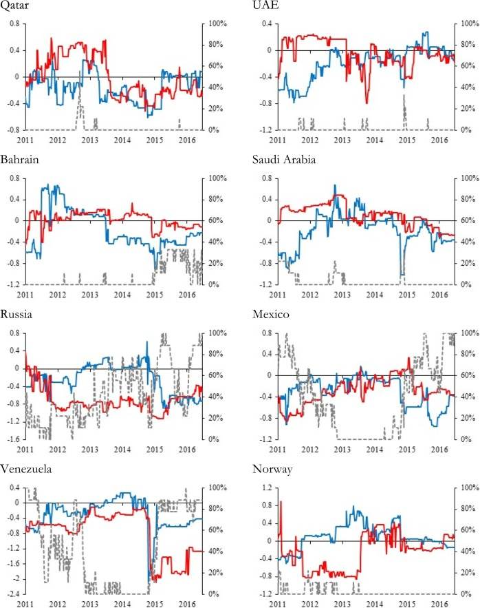

Fig. 3. Rolling-window quantile regression estimates of the impact of WTI oil returns on SCDS spreads.

Note: Time-variation of the quantile [regression coefficients](https://www.sciencedirect.com/topics/engineering/regression-coefficient) for oil returns. The blue (red) solid line is the 10% (90%) quantile. Other quantiles assume in most cases values between or close to those two limiting quantiles. The dashed grey line is the fraction of the statistically significant coefficients across the quantiles. (For interpretation of the references to color in this figure legend, the reader is referred to the web version of this article.)

As can be observed from Fig. 3, we note that the coefficients are quite different across the quantiles and over time periods. The coefficients are mostly insignificant for both quantiles in the case of Qatar, UAE and Saudi Arabia (see the dashed grey line showing the fraction of statistically significant coefficients across quantiles). A sample period of significant negative impacts in the lowest quantile of SDCS spreads is evident for Saudi Arabia during 2015. Oil price returns negatively impact the SDCS spread of Bahrain for both the lowest and highest quantiles but this impact is only significant towards the end of the sample period, that is, after 2015. Similarly for Russia, the negative impact of oil price returns on SDCS spreads gradually becomes significant and this negative impact is highest towards the end of the sample period again after 2015.

For Mexico and Venezuela, the high negative and significant impact of oil price returns is evident on the lowest and highest quantiles of SDCS spreads at the beginning of the sample (2011–2012) and then again towards the end of the sample period. In the case of Norway, the quantile coefficients are mostly insignificant. It is worth mentioning that the negative impact of oil price returns on SCDS spreads is higher and mostly becomes significant after 2015. This period is marked with the lower oil prices and thus it is important for policymakers to note that the negative impact of oil prices becomes more relevant when the oil prices are on a downward trend. These findings are in line with the conclusion drawn by Shahzad et al. (2017).

The rolling window-based quantile estimates provide evidence of the changes in the impact of oil returns on the sovereign CDS spreads across the quantiles. As a further check, we focus on the quantile-on-quantile (QQ) approach. Similarly to Sim and Zhou (2015), we graphically represent the [estimated coefficients](https://www.sciencedirect.com/topics/engineering/estimated-coefficient) using the surface plots. The QQ approach helps us in capturing the variations in the relationship between the SCDS spreads and oil returns at each point of their conditional distributions, hence providing a clear and complete picture of the dependency relationship. Fig. 4 plots the quantile-on-quantile estimates of the impact of oil price returns on the CDS spreads by conditioning on the quantile levels of both variables.

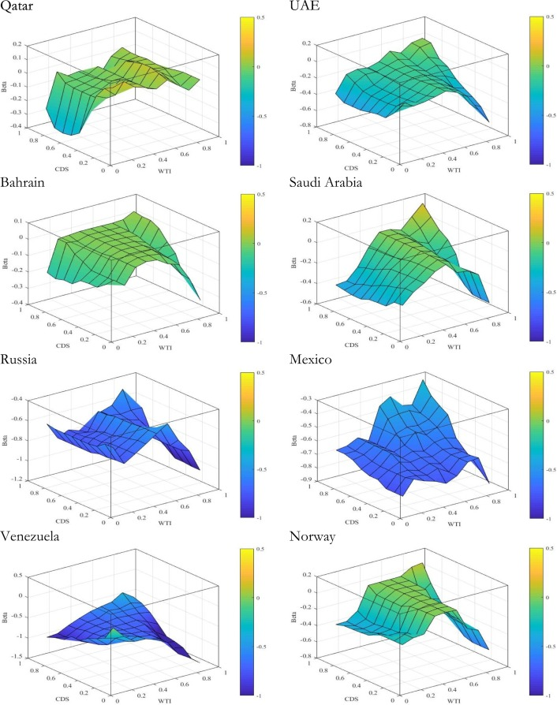

Fig. 4. The quantile-on-quantile estimates of the impact of WTI oil returns on SCDS spreads by conditioning on the corresponding quantiles.

Note: These graphs depict the estimates of the slope coefficient, *β*<sub>1</sub>(*θ*, *τ*), which is placed on the z-axis against the quantiles of the [CDS](https://www.sciencedirect.com/topics/economics-econometrics-and-finance/credit-derivative) returns (θ) on the x-axis and the quantiles of oil returns (τ) on the y-axis. (For interpretation of the references to color in this figure, the reader is referred to the web version of this article.)

The QQ analysis presented in Fig. 4 illustrates the estimates of the slope coefficient β_1 (θ,τ), which captures the effect of the τth quantile of oil returns and its decomposed series on the θth quantile of the SCDS spreads at dissimilar values of θ and τ. The figures across countries adopt the same scale and color grading so that a comparison is immediate. The color bar on the right side of each figure shows the strength of the relationship, where the blue color indicates negative beta coefficients, while the yellow color presents positive values of the coefficients. However, the light green color implies no relationship. In the case of Qatar, oil returns have no impact on the SCDS spreads but they have a negative impact only in the lowest quantile (bearish market state). For UAE, oil returns generally have a negative effect on SCDS returns; however, this negative impact is more profound when the oil market is bullish (i.e. upper quantile) and the SCDS markets are bearish (i.e. lower quantiles). Somewhat a similar relation is found for Bahrain. We note that the impacts of oil returns on sovereign CDS are higher and more negative (more favorable) in the case of Mexico, Venezuela and Russia. For Saudi Arabia and Norway, oil returns do not impact the SCDS spreads when both markets are in the normal state (middle quantiles); however, the negative relation is heterogeneous in the extreme states of both markets.

All in all, we find that oil price returns significantly and negatively impact the SCDS spreads of oil-exporting countries other than the GCC countries and that these impacts are time-varying and heterogeneous across different market states in both oil and SCDS markets.

## 5. Conclusions

The sovereign credit risk is an important topic of consideration for international investors seeking portfolio investments in emerging markets and diversification in different countries and regions/blocks. The world's sovereign CDS markets have also been used as a market-based reference for the sovereign credit risk. Three facts have motivated us to examine the sovereign credit risk for oil-exporting countries in this study. The first fact relates to the alarming widening of the sovereign CDS spreads in credit markets in the wake of the drastic drops in oil prices and increases in uncertainty. The recent 2014–2016 and 2020 oil price collapse periods have renewed the debate about the impact of oil prices and global financial uncertainty on sovereign CDS markets, particularly for oil-exporting countries. The second fact acknowledges that there are no in-depth empirical studies that address the impacts of oil price and global financial factors on the sovereign credit risk of oil-exporting countries under different market conditions.

The third fact has to do with the lack of empirical research that detects the impact of the global oil market, global financial risk and uncertainty factors on sovereign CDS spreads of the oil-rich GCC and other important oil-exporting countries like Mexico, Norway, Russia and Venezuela. The comparison is particularly relevant to the GCC countries since they have entered an important era in which they increasingly want to open up to foreign investors and borrow large amounts of money from international financial centers at reasonable costs of capital to lengthen the lifespan of their foreign asset endowments. It is particularly important for Venezuela and Russia which face high [geopolitical risks](https://www.sciencedirect.com/topics/economics-econometrics-and-finance/geopolitical-risks).

Firstly, we use the quantile regression analysis that allows one to investigate the dependence dynamics of the sovereign CDS spreads of those countries under different market conditions, including the states of bull, bear and normal markets. The empirical results show a different dependence structure between sovereign credit risk premiums and global financial risk and uncertainty factors across quantiles and across oil-exporting countries. We find that the important non GCC oil exporters Venezuela, Mexico and Russia are the countries most affected by oil prices across all quantiles. However, no dependence (or just weak dependence limited in a few quantiles) is observed between oil market returns and volatility and sovereign credit risk spreads in the case of Saudi Arabia, UAE and Norway, although these countries are considered as major players in the global oil market. This finding can be explained by the fact that these countries have huge sovereign wealth funds that help cushion them from global shocks and therefore, their sovereign CDS spreads are less affected by the volatility of oil prices. This result for the GCC countries must be conditioned on the continuing possession of large foreign assets. A diminution in the size of those assets should have different implications for the magnitude of their CDS premiums, as we have seen in the case of Venezuela, Mexico, and Russia.

Secondly, as a robustness check and due to their differential advantages, we employ the rolling quantile regression and the quantile-in-quantile (QQ) approach that allow one to investigate the dependence dynamics of the sovereign CDS spreads of the oil-exporting countries under different market conditions. The QQ analysis is flexible and offers a complete approach for examining how the explanatory variables affect the location, scale and shape of the entire change in the sovereign CDS distributions. The empirical results show that the oil price returns significantly decrease the sovereign credit risk premium of the non-GCC oil-exporting countries namely Venezuela, Mexico, and Russia. Moreover, we have evidence suggesting the presence of a non-linear link between the oil returns, financial uncertainty, and sovereign CDS premiums. The increase in the credit risk premiums as a result of a higher oil price volatility or financial uncertainty has implications for the capital-borrowing costs, the values of currencies that are pegged to an anchor and the levels of financial spreads which are important for investments. The rise in the sovereign credit risk premiums affects banks and funding conditions, and also impacts the level and volatility of sovereign bond yields, mainly on the term of maturity, and thereby influences the sovereign liquidity risk.

Policymakers and sovereign debt managers in oil-exporting countries should be cognizant of our empirical results and should seek to minimize the medium- to long-term expected costs of funding [government activities](https://www.sciencedirect.com/topics/economics-econometrics-and-finance/government-activity), mainly when oil volatility and financial uncertainty follow a rising trend. Our findings also help gauge which countries under consideration are more sensitive to oil price volatility and global financial uncertainties, and how this sensitivity translates into increased sovereign credit risks.

## Authors' contribution statement

**Nader Naifar**: Conceptualization; Methodology, Investigation; Writing - Original Draft.

**Syed Jawad Hussain Shahzad**: Methodology; Software; Investigation; Formal analysis.

**Shawkat Hammoudeh**: Writing - Review & Editing, Investigation; Visualization, Validation.

## Appendix A. Supplementary data

[Download: Download zip file (61KB)](https://ars.els-cdn.com/content/image/1-s2.0-S0140988320300864-mmc1.zip)

Supplementary material

## References

1. Alter and Schüler, 2012

   A. Alter, Y.S. Schüler

   Credit spread interdependencies of European states and banks during the financial crisis

   J. Bank. Financ., 36 (12) (2012), pp. 3444-3468

   [View PDF](https://www.sciencedirect.com/science/article/pii/S0378426612002221/pdfft?md5=2a145acb43e5e0f1ea6710c2a9592b62&pid=1-s2.0-S0378426612002221-mainext.pdf)[View article](https://www.sciencedirect.com/science/article/pii/S0378426612002221)[View in Scopus](https://www.scopus.com/inward/record.url?eid=2-s2.0-84866846024&partnerID=10&rel=R3.0.0)Google Scholar
2. Ang and Longstaff, 2013

   A. Ang, F.A. Longstaff

   Systemic sovereign credit risk: lessons from the U.S. and Europe

   J. Monet. Econ., 60 (5) (2013), pp. 493-510

   [View PDF](https://www.sciencedirect.com/science/article/pii/S0304393213000585/pdfft?md5=386d4260deb89414f9c6827da70b6122&pid=1-s2.0-S0304393213000585-main.pdf)[View article](https://www.sciencedirect.com/science/article/pii/S0304393213000585)[View in Scopus](https://www.scopus.com/inward/record.url?eid=2-s2.0-84881111988&partnerID=10&rel=R3.0.0)[Google Scholar](https://scholar.google.com/scholar_lookup?title=Systemic%20sovereign%20credit%20risk%3A%20lessons%20from%20the%20U.S.%20and%20Europe&publication_year=2013&author=A.%20Ang&author=F.A.%20Longstaff)
3. Baum and Wan, 2010

   C.F. Baum, C. Wan

   Macroeconomic uncertainty and credit default swap spreads

   Appl. Financ. Econ., 20 (2010), pp. 1163-1171

   [Crossref](https://doi.org/10.1080/09603101003781455)[View in Scopus](https://www.scopus.com/inward/record.url?eid=2-s2.0-77954717301&partnerID=10&rel=R3.0.0)[Google Scholar](https://scholar.google.com/scholar_lookup?title=Macroeconomic%20uncertainty%20and%20credit%20default%20swap%20spreads&publication_year=2010&author=C.F.%20Baum&author=C.%20Wan)
4. Bouri et al., 2018

   E. Bouri, S.J.H. Shahzad, N. Raza, D. Roubaud

   Oil volatility and sovereign risk of BRICS

   Energy Econ., 70 (2018), pp. 258-269

   [View PDF](https://www.sciencedirect.com/science/article/pii/S0140988317304383/pdfft?md5=dcb715762f4a718bceb2ef700eab621b&pid=1-s2.0-S0140988317304383-main.pdf)[View article](https://www.sciencedirect.com/science/article/pii/S0140988317304383)[View in Scopus](https://www.scopus.com/inward/record.url?eid=2-s2.0-85042779866&partnerID=10&rel=R3.0.0)[Google Scholar](https://scholar.google.com/scholar_lookup?title=Oil%20volatility%20and%20sovereign%20risk%20of%20BRICS&publication_year=2018&author=E.%20Bouri&author=S.J.H.%20Shahzad&author=N.%20Raza&author=D.%20Roubaud)
5. Chuffart and Hooper, 2019

   T. Chuffart, E. Hooper

   An investigation of oil prices impact on sovereign credit default swaps in Russia and Venezuela

   Post-Print hal-02194152, HAL (2019)

   Google Scholar
6. Dickey and Fuller, 1979

   D.A. Dickey, W.A. Fuller

   Distribution of the estimators for autoregressive time series with a unit root

   J. Am. Stat. Assoc., 74 (366a) (1979), pp. 427-431

   Google Scholar
7. Dieckmann and Plank, 2012

   S. Dieckmann, T. Plank

   Default risk of advanced economies: an empirical analysis of credit default swaps during the financial crisis

   Rev. Finan., 16 (4) (2012), pp. 903-934

   [Crossref](https://doi.org/10.1093/rof/rfr015)[View in Scopus](https://www.scopus.com/inward/record.url?eid=2-s2.0-84866604022&partnerID=10&rel=R3.0.0)Google Scholar
8. Koenker, 2005

   R. Koenker

   Quantile Regression

   Cambridge University Press (2005)

   [Google Scholar](https://scholar.google.com/scholar_lookup?title=Quantile%20Regression&publication_year=2005&author=R.%20Koenker)
9. Koenker and Bassett, 1978

   R. Koenker, G. Bassett

   Regression quantiles

   Econometrica, 46 (1) (1978), pp. 33-50

   [Crossref](https://doi.org/10.2307/1913643)[View in Scopus](https://www.scopus.com/inward/record.url?eid=2-s2.0-85132738777&partnerID=10&rel=R3.0.0)[Google Scholar](https://scholar.google.com/scholar_lookup?title=Regression%20quantiles&publication_year=1978&author=R.%20Koenker&author=G.%20Bassett)
10. Koenker and Hallock, 2003

    R. Koenker, K. Hallock

    Quantile regression

    J. Econ. Perspect., 15 (2003), pp. 143-156

    [Google Scholar](https://scholar.google.com/scholar_lookup?title=Quantile%20regression&publication_year=2003&author=R.%20Koenker&author=K.%20Hallock)
11. Kwiatkowski et al., 1992

    D. Kwiatkowski, P.C. Phillips, P. Schmidt, Y. Shin

    Testing the null hypothesis of stationarity against the alternative of a unit root: how sure are we that economic time series have a unit root

    J. Econ., 54 (1–3) (1992), pp. 159-178

    [View PDF](https://www.sciencedirect.com/science/article/pii/030440769290104Y/pdf?md5=dfa64f3eb2ea53d035a0208c39ffec29&pid=1-s2.0-030440769290104Y-main.pdf)[View article](https://www.sciencedirect.com/science/article/pii/030440769290104Y)[View in Scopus](https://www.scopus.com/inward/record.url?eid=2-s2.0-34247480179&partnerID=10&rel=R3.0.0)Google Scholar
12. Longstaff et al., 2011

    F. Longstaff, J. Pan, L.H. Pedersen, K.J. Singleton

    How sovereign is sovereign risk?

    Am. Econ. J. Macroecon., 3 (2011), pp. 75-103

    [Crossref](https://doi.org/10.1257/mac.3.2.75)[View in Scopus](https://www.scopus.com/inward/record.url?eid=2-s2.0-79958088403&partnerID=10&rel=R3.0.0)[Google Scholar](https://scholar.google.com/scholar_lookup?title=How%20sovereign%20is%20sovereign%20risk&publication_year=2011&author=F.%20Longstaff&author=J.%20Pan&author=L.H.%20Pedersen&author=K.J.%20Singleton)
13. Narayana et al., 2014

    P. Narayana, S. Sharma, W. Poon, J. Westerlund

    Do oil prices predict economic growth? New global evidence

    Energy Econ., 41 (2014), pp. 137-146

    Google Scholar
14. Pan and Singleton, 2008

    J. Pan, K.J. Singleton

    Default and recovery implicit in the term structure of sovereign CDS spreads

    J. Financ., 63 (2008), pp. 2345-2384

    [Crossref](https://doi.org/10.1111/j.1540-6261.2008.01399.x)[View in Scopus](https://www.scopus.com/inward/record.url?eid=2-s2.0-48549106155&partnerID=10&rel=R3.0.0)[Google Scholar](https://scholar.google.com/scholar_lookup?title=Default%20and%20recovery%20implicit%20in%20the%20term%20structure%20of%20sovereign%20CDS%20spreads&publication_year=2008&author=J.%20Pan&author=K.J.%20Singleton)
15. Shahzad et al., 2017

    S.J.H. Shahzad, N. Naifar, S. Hammoudeh, D. Roubaud

    Directional predictability from oil market uncertainty to sovereign credit spreads of oil-exporting countries: evidence from rolling windows and crossquantilogram analysis

    Energy Econ., 68 (2017), pp. 327-339

    [View PDF](https://www.sciencedirect.com/science/article/pii/S0140988317303298/pdfft?md5=573716496785814c5d16d9c1310c13c5&pid=1-s2.0-S0140988317303298-main.pdf)[View article](https://www.sciencedirect.com/science/article/pii/S0140988317303298)[View in Scopus](https://www.scopus.com/inward/record.url?eid=2-s2.0-85033473522&partnerID=10&rel=R3.0.0)Google Scholar
16. Sharma and Thuraisamy, 2013

    S.S. Sharma, K. Thuraisamy

    Oil price uncertainty and sovereign risk: evidence from Asian economies

    J. Asian Econ., 28 (2013), pp. 51-57

    [View PDF](https://www.sciencedirect.com/science/article/pii/S1049007813000602/pdfft?md5=7ec5e49c83d57ff278c609440a4889e6&pid=1-s2.0-S1049007813000602-main.pdf)[View article](https://www.sciencedirect.com/science/article/pii/S1049007813000602)[View in Scopus](https://www.scopus.com/inward/record.url?eid=2-s2.0-84885936994&partnerID=10&rel=R3.0.0)[Google Scholar](https://scholar.google.com/scholar_lookup?title=Oil%20price%20uncertainty%20and%20sovereign%20risk%3A%20evidence%20from%20Asian%20economies&publication_year=2013&author=S.S.%20Sharma&author=K.%20Thuraisamy)
17. Sim and Zhou, 2015

    N. Sim, H. Zhou

    Oil prices, US stock returns, and the dependence between their quantiles

    J. Bank. Financ., 55 (2015), pp. 1-8

    [View PDF](https://www.sciencedirect.com/science/article/pii/S0378426615000217/pdfft?md5=72b4bed55ac2934b123412c25fd2f888&pid=1-s2.0-S0378426615000217-main.pdf)[View article](https://www.sciencedirect.com/science/article/pii/S0378426615000217)[View in Scopus](https://www.scopus.com/inward/record.url?eid=2-s2.0-84924032470&partnerID=10&rel=R3.0.0)[Google Scholar](https://scholar.google.com/scholar_lookup?title=Oil%20prices%2C%20US%20stock%20returns%2C%20and%20the%20dependence%20between%20their%20quantiles&publication_year=2015&author=N.%20Sim&author=H.%20Zhou)

- 2023, International Review of Financial Analysis

  Citation Excerpt :

- 2022, Research in International Business and Finance

  Citation Excerpt :

- 2021, Resources Policy

- 2021, Journal of International Financial Markets Institutions and Money

- 2020, Energy Economics

- 2022, Environmental Science and Pollution Research

**<sup>1</sup>**

The terms bearish and bullish in the case of credit markets are different from those commonly used in equity markets. Downturns in CDS spreads do not mean bad but good conditions. Decreases in SCDS mean decreases in credit risk, and thus, a negative impact on SCDS spreads implies a good sign for the economy.

**<sup>2</sup>**

https://www.reuters.com/article/us-bahrain-economy/saudi-kuwait-uae-to-sign-10-billion-bahrain-aid-deal-kuwait-newspaper-idUSKCN1ME0GC.

**<sup>3</sup>**

https://www.cairn.info/revue-economie-internationale-2010-3-page-121.htm?try_download=1.

**<sup>4</sup>**

We use weekly data instead of daily because there is not much change in sovereign CDS spreads across days. The CDS spreads of almost all the oil-exporting countries do not change on daily basis and since there are very small daily variations and most of the time we get zero values for the changes in the CDS spreads when we use the daily data, hence the results were not reliable. Further, the Quantile based methods are usually applied to weekly or monthly data. Different trading time zones also require the use of weekly data.

**<sup>5</sup>**

Narayana et al. (2014) show that the nominal oil price predicts economic growth for 37 countries (16 developing and 21 developed countries) for the period 1983Q2 to 2010Q4.

**<sup>6</sup>**

Norway has the largest sovereign wealth fund in the world and a relatively more diversified economy, and thus, it is less affected by changes in oil prices than the GCC countries. https://www.swfinstitute.org/fund-rankings/sovereign-wealth-fund.

**<sup>7</sup>**

https://www.cnbc.com/2015/07/17/the-worlds-biggest-sovereign-wealth-funds.html.

[View Abstract](https://www.sciencedirect.com/science/article/abs/pii/S0140988320300864)

© 2020 Elsevier B.V. All rights reserved.

  Luis A. Gil-Alana, …, Yener Coskun

  [View PDF](https://www.sciencedirect.com/science/article/pii/S1059056020300836/pdfft?md5=52d3b1b31bec8236c10418a53ed53362&pid=1-s2.0-S1059056020300836-main.pdf)

  Zhiqing Xia, …, Ge Song

  [View PDF](https://www.sciencedirect.com/science/article/pii/S0301479720312482/pdfft?md5=e8b180fe512d038bc11a8f8e72db09fa&pid=1-s2.0-S0301479720312482-main.pdf)

  Afees A. Salisu, …, Brian Lucey

  [View PDF](https://www.sciencedirect.com/science/article/pii/S0275531921000453/pdfft?md5=593f7f42e3a9e5f820e2e236f9f488a8&pid=1-s2.0-S0275531921000453-main.pdf)